# Unit transformation strategy comparison for Data-driven analysis of isobarically labeled proteomic data.

Joris Van Houtven, Piotr Prostko

January 13, 2021,22:07

```r
library(ggplot2)
library(stringi)
library(gridExtra)
library(dendextend)
library(kableExtra)
library(limma)
library(psych)
library(tidyverse)
library(CONSTANd)  # install from source: https://github.com/PDiracDelta/CONSTANd/
source('./other_functions.R')
source('./plotting_functions.R')
```

```r
# set load_outputdata=TRUE if you want to skip long computations (normalization and DEA) and just load the previously saved data sets
load_outputdata=TRUE
data.list <- readRDS('input_data.rds')
dat.l <- data.list$dat.l # data in long format
# which proteins were spiked in?
spiked.proteins <- dat.l %>% distinct(Protein) %>% filter(stri_detect(Protein, fixed='ups')) %>% pull %>% as.character
#TEMP -remove!
# tmp=dat.l %>% distinct(Protein) %>% pull %>% as.character
# dat.l <- dat.l %>% filter(Protein %in% c(tmp[sample(1:length(tmp), size=20)], spiked.proteins))
```

```r
# specify # of varying component variants and their names
variant.names <- c('log2_intensity', 'intensity', 'ratio')
n.comp.variants <- length(variant.names)
scale.vec <- c('log', 'raw', 'raw')  # ratios are considered raw, because they are basically mean-normalized intensities
# pick reference condition for making plots / doing DEA
referenceCondition <- '0.5'
# specify colours corresponding to biological conditions
condition.color <- tribble(
  ~Condition, ~Color,
  "0.125", 'black',
  "0.5", 'blue',
  "0.667", 'green',
  "1", 'red' )
# create data frame with sample info (distinct Run,Channel, Sample, Condition, Color)
sample.info <- get_sample_info(dat.l, condition.color)
channelNames <- remove_factors(unique(sample.info$Channel))
```

# 1 Unit scale component

```r
dat.unit.l <- emptyList(variant.names)
```

## 1.1 log2 transformation of reporter ion intensities

```r
dat.unit.l$log2_intensity <- dat.l %>% mutate(response=log2(intensity)) %>% select(-intensity)
```

## 1.2 intensities on the original scale

```r
dat.unit.l$intensity <- dat.l %>% rename(response=intensity)
```

## 1.3 intensity ratios

Calculate ratio (per PSM) with respect to average intensity within run, or in other words: each value is divided by the row mean.

```r
# use half-wide data to compute within-run average of PSM channels corresponding to the reference Condition
refCols <- sample.info %>% distinct(Channel) %>% pull(Channel)
denom.df=dat.l %>% pivot_wider(id_cols=-one_of('Condition', 'BioReplicate'),names_from='Channel', values_from='intensity')
denom.df$denom=apply(denom.df[,refCols], 1, function(x) mean(x, na.rm=T))
denom.df=denom.df[,c('Run', 'Protein', 'Peptide', 'RT', 'Charge', 'PTM', 'denom')]
dat.unit.l$ratio <- dat.l %>% left_join(denom.df[c('Run', 'Protein', 'Peptide', 'RT', 'Charge', 'PTM', 'denom')], by=c('Run', 'Protein', 'Peptide', 'RT', 'Charge', 'PTM')) %>% mutate(response=intensity/denom) %>% select(-c(intensity, denom))
```

# 2 Normalization component: medianSweeping (1)

```r
if (!load_outputdata){
# switch to wide format
dat.unit.w <- lapply(dat.unit.l, function(x){
  pivot_wider(data = x, id_cols=-one_of(c('Condition', 'BioReplicate')), names_from=Channel, values_from=response)})
}
```

```r
if (!load_outputdata){
# subtract the spectrum median log2intensity from the observed log2intensities
dat.norm.w <- dat.unit.w
dat.norm.w$log2_intensity[,channelNames] <- median_sweep(dat.norm.w$log2_intensity[,channelNames], 1, '-')
dat.norm.w$intensity[,channelNames] <- median_sweep(dat.norm.w$intensity[,channelNames], 1, '/')
dat.norm.w$ratio[,channelNames] <- median_sweep(dat.norm.w$ratio[,channelNames], 1, '/')
}
```

# 3 Summarization component: Median summarization

Summarize quantification values from PSM to peptide (first step) to protein (second step).

```r
if (!load_outputdata){
# normalized data
dat.norm.summ.w <- lapply(dat.norm.w, function(x){
  y <- x %>% group_by(Run, Protein, Peptide) %>% summarise_at(.vars = channelNames, .funs = median, na.rm=T) %>% summarise_at(.vars = channelNames, .funs = median, na.rm=T) %>% ungroup()
  return(y)})
}
```

Let’s also summarize the non-normalized data for comparison in the next section.

```r
if (!load_outputdata){
# non-normalized data
# group by (run,)protein,peptide then summarize twice (once on each level)
# add select() statement because summarise_at is going bananas over character columns
dat.nonnorm.summ.w <- lapply(dat.unit.w, function(x) {
  y <- x %>% group_by(Run, Protein, Peptide) %>% summarise_at(.vars = channelNames, .funs = median, na.rm=T) %>% summarise_at(.vars = channelNames, .funs = median, na.rm=T) %>% ungroup()
  return(y)})
}
```

# 4 Normalization component: medianSweeping (2)

```r
if (!load_outputdata){
# medianSweeping: in each channel, subtract/divide median computed across all proteins within the channel
# do the above separately for each MS run
second_median_sweep <- function(dat, fun){
  dat.split <- split(dat, dat$Run)
  dat.split.norm  <- lapply(dat.split, function(y) {
    y[,channelNames] <- median_sweep(y[,channelNames], 2, fun); return(y)})
  return(bind_rows(dat.split.norm))
}
dat.norm.summ.w$log2_intensity <- second_median_sweep(dat.norm.summ.w$log2_intensity, '-')
dat.norm.summ.w$intensity <- second_median_sweep(dat.norm.summ.w$intensity, '/')
dat.norm.summ.w$ratio <- second_median_sweep(dat.norm.summ.w$ratio, '/')
}
```

# 5 QC plots

```r
if (!load_outputdata){
# make data completely wide (also across runs)
## normalized data
dat.norm.summ.w2 <- lapply(dat.norm.summ.w, function(x) {
  return( x %>% pivot_wider(names_from = Run, values_from = all_of(channelNames), names_glue = "{Run}:{.value}") )
})

## non-normalized data
dat.nonnorm.summ.w2 <- lapply(dat.nonnorm.summ.w, function(x) {
  return( x %>% pivot_wider(names_from = Run, values_from = all_of(channelNames), names_glue = "{Run}:{.value}") )
})
}
```

## 5.1 Boxplots

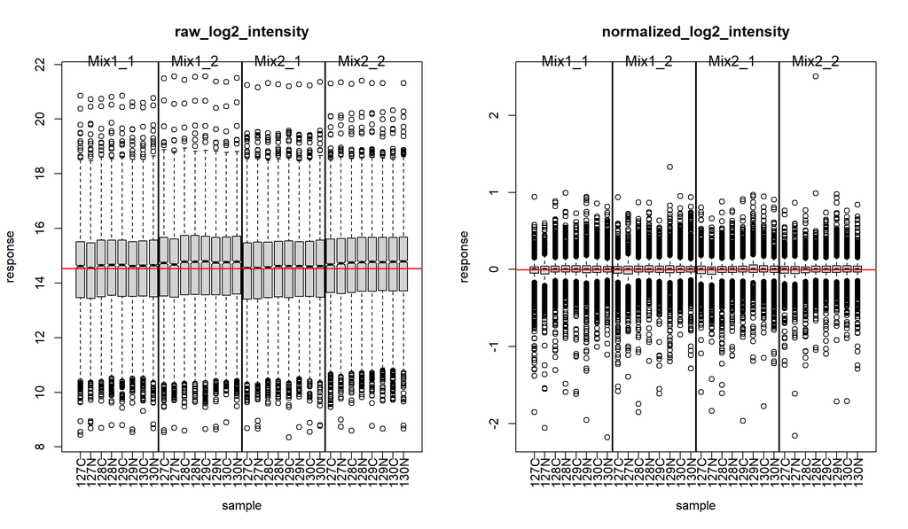

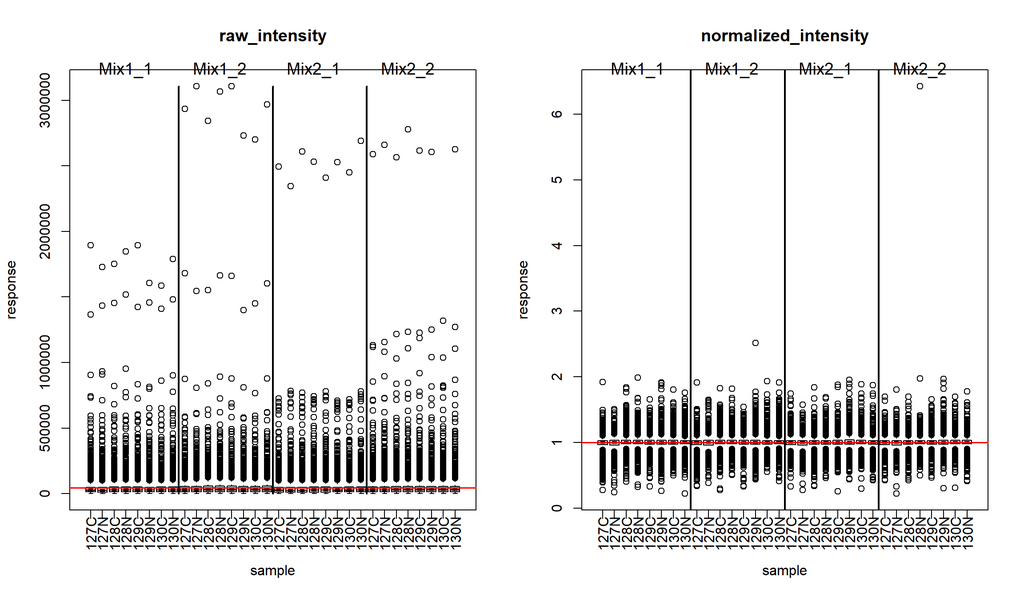

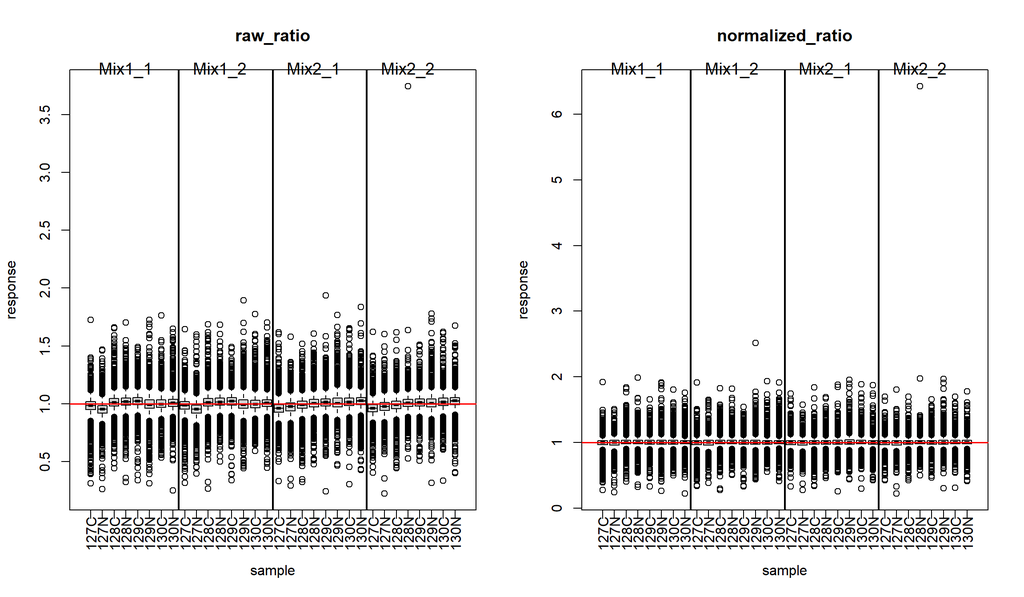

```r
# use (half-)wide format
par(mfrow=c(1,2))
for (i in 1:n.comp.variants){
  boxplot_w(dat.nonnorm.summ.w[[variant.names[i]]],sample.info, paste('raw', variant.names[i], sep='_'))
  boxplot_w(dat.norm.summ.w[[variant.names[i]]], sample.info, paste('normalized', variant.names[i], sep='_'))}
```

## 5.2 MA plots

MA plots of two single samples taken from condition 1 and condition 0.125, measured in different MS runs (samples *Mixture2_1:127C* and *Mixture1_2:129N*, respectively).

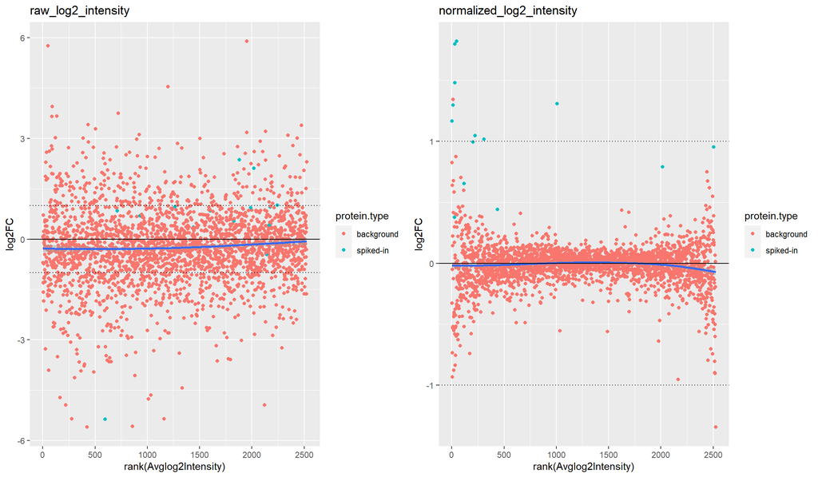

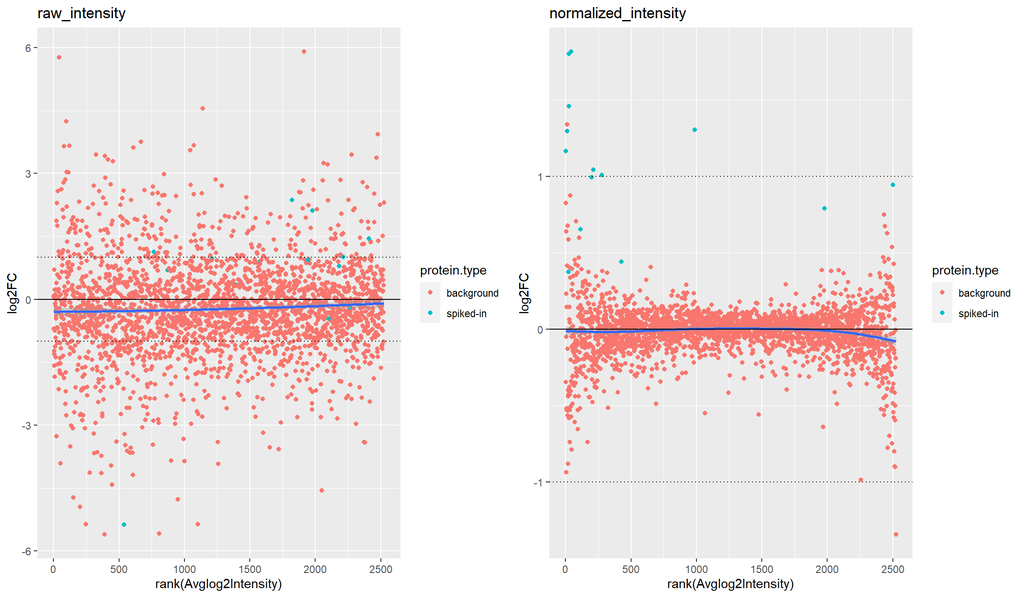

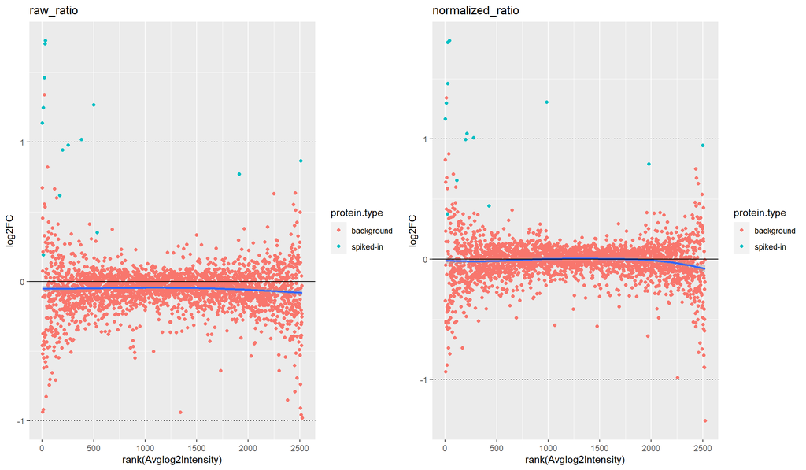

```r
for (i in 1:n.comp.variants){
  p1 <- maplot_ils(dat.nonnorm.summ.w2[[variant.names[i]]], 'Mixture2_1:127C', 'Mixture1_2:129N', scale=scale.vec[i], paste('raw', variant.names[i], sep='_'), spiked.proteins)
  p2 <- maplot_ils(dat.norm.summ.w2[[variant.names[i]]], 'Mixture2_1:127C', 'Mixture1_2:129N', scale=scale.vec[i], paste('normalized', variant.names[i], sep='_'), spiked.proteins)
grid.arrange(p1, p2, ncol=2)}
```

MA plots of all samples from condition `1` and condition `0.125` (quantification values averaged within condition).

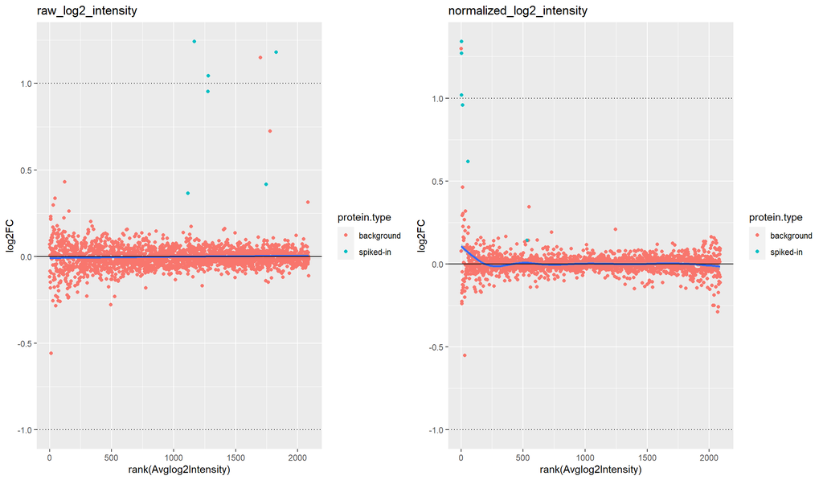

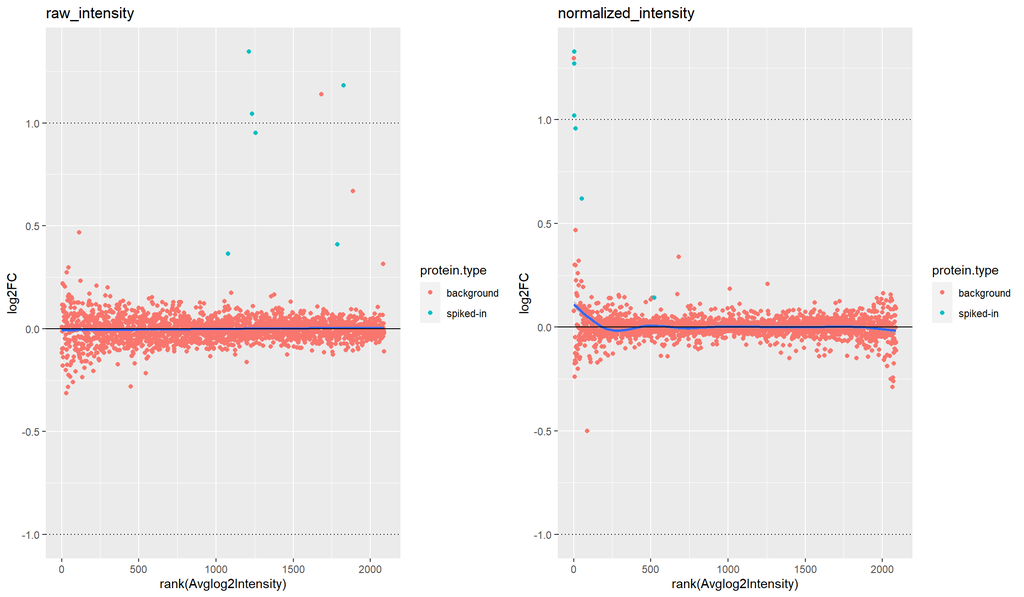

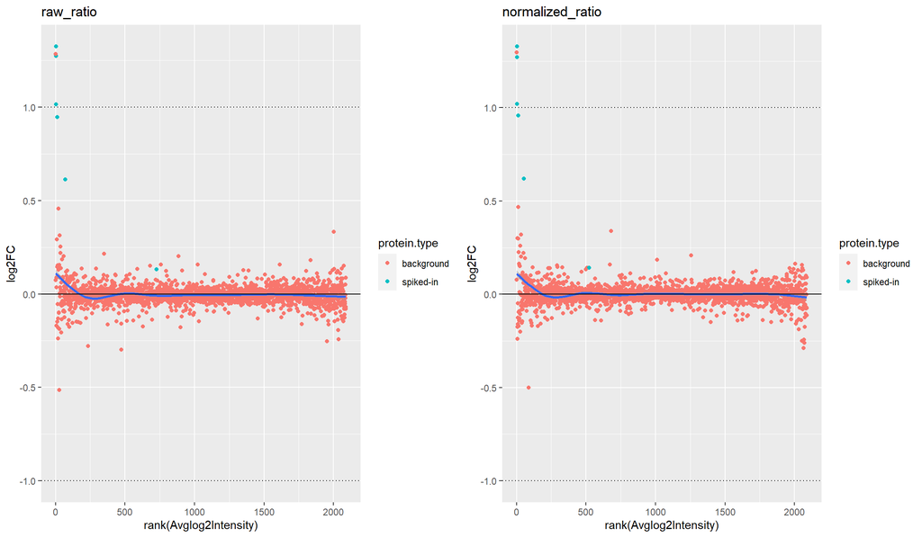

```r
channels.num <- sample.info %>% filter(Condition=='1') %>% select(Sample) %>% pull
channels.denom <- sample.info %>% filter(Condition=='0.125') %>% select(Sample) %>% pull
for (i in 1:n.comp.variants){
  p1 <- maplot_ils(dat.nonnorm.summ.w2[[variant.names[i]]], channels.num, channels.denom, scale=scale.vec[i], paste('raw', variant.names[i], sep='_'), spiked.proteins)
  p2 <- maplot_ils(dat.norm.summ.w2[[variant.names[i]]], channels.num, channels.denom, scale=scale.vec[i], paste('normalized', variant.names[i], sep='_'), spiked.proteins)
grid.arrange(p1, p2, ncol=2)}
```

## 5.3 PCA plots

### 5.3.1 Using all proteins

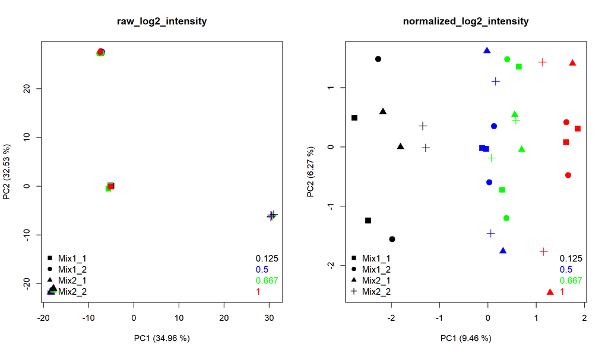

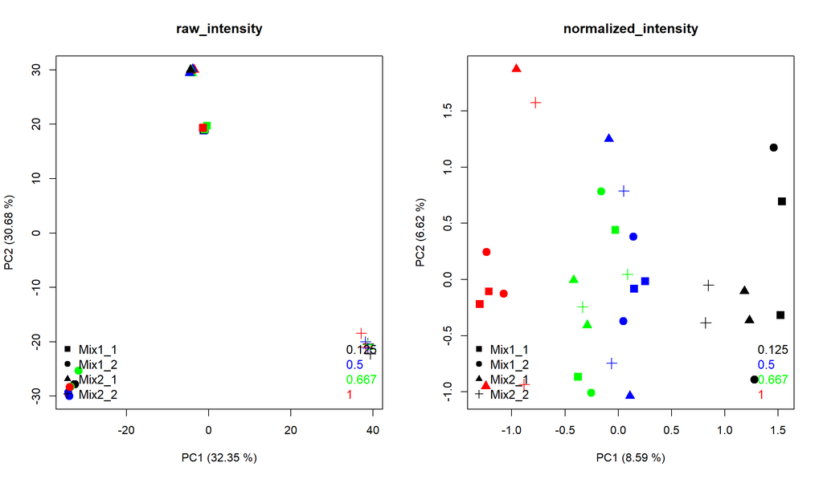

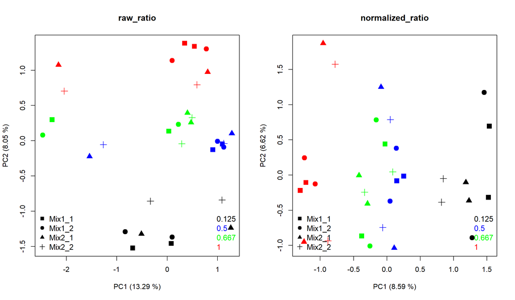

```r
par(mfrow=c(1, 2))
for (i in 1:n.comp.variants){
  if (variant.names[i]=='intensity') pca.scale=TRUE else pca.scale=FALSE
  pcaplot_ils(dat.nonnorm.summ.w2[[variant.names[i]]] %>% select(-'Protein'), info=sample.info, paste('raw', variant.names[i], sep='_'), scale=pca.scale)
  pcaplot_ils(dat.norm.summ.w2[[variant.names[i]]] %>% select(-'Protein'), info=sample.info, paste('normalized', variant.names[i], sep='_'))}
```

### 5.3.2 Using spiked proteins only

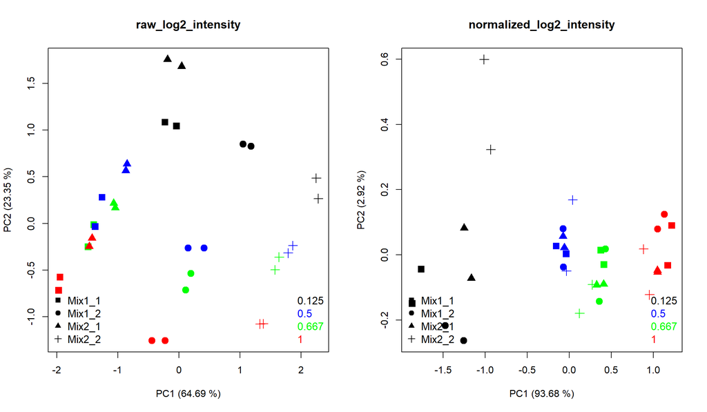

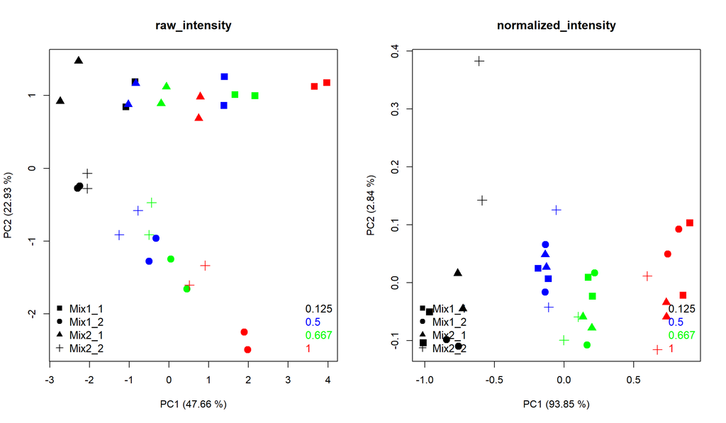

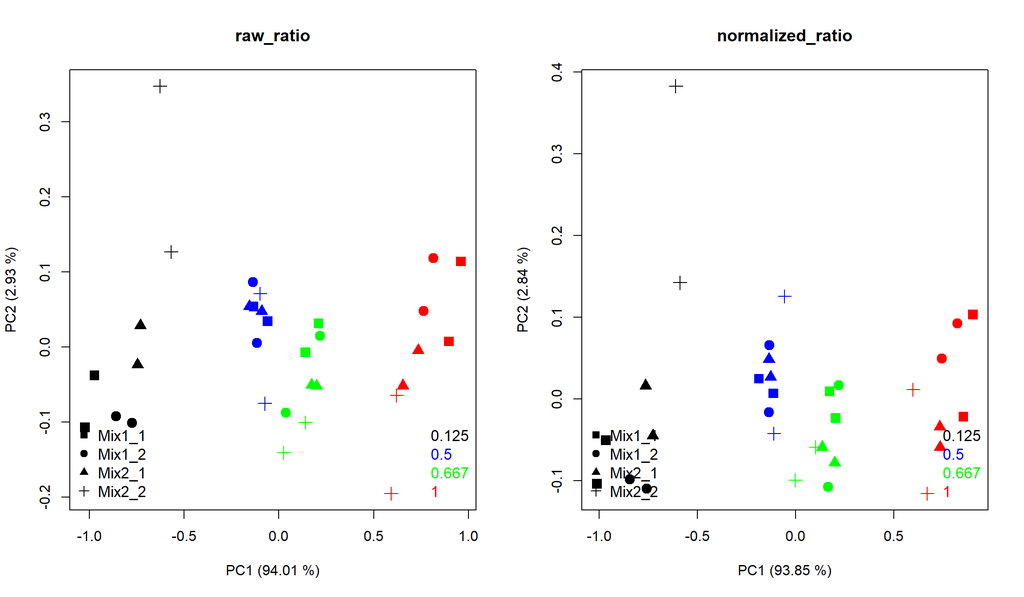

```r
par(mfrow=c(1, 2))
for (i in 1:n.comp.variants){
  if (variant.names[i]=='intensity') pcaplot_ils(dat.nonnorm.summ.w2[[variant.names[i]]] %>% filter(Protein %in% spiked.proteins) %>% select(-'Protein'), info=sample.info, paste('raw', variant.names[i], sep='_'), scale=T) else pcaplot_ils(dat.nonnorm.summ.w2[[variant.names[i]]] %>% filter(Protein %in% spiked.proteins) %>% select(-'Protein'), info=sample.info, paste('raw', variant.names[i], sep='_'))
  pcaplot_ils(dat.norm.summ.w2[[variant.names[i]]] %>% filter(Protein %in% spiked.proteins) %>% select(-'Protein'), info=sample.info, paste('normalized', variant.names[i], sep='_'))}
```

## 5.4 HC (hierarchical clustering) plots

### 5.4.1 Using all proteins

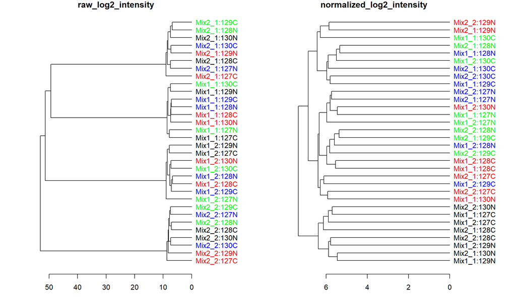

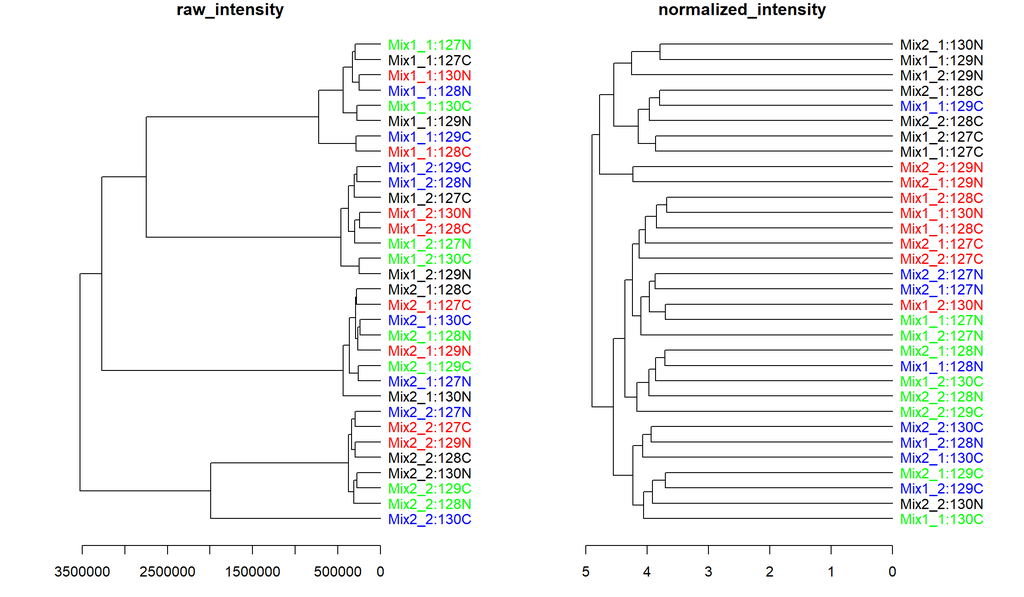

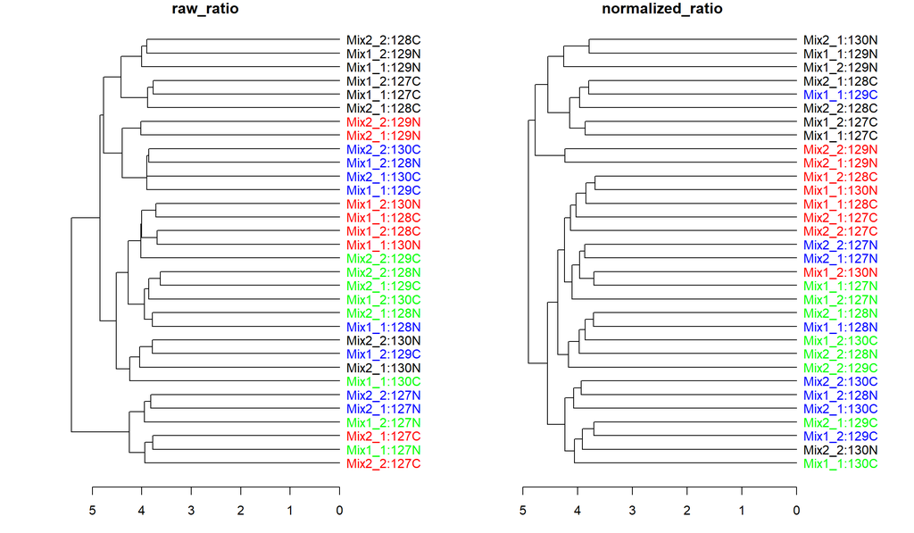

```r
par(mfrow=c(1,2))
for (i in 1:n.comp.variants){
  dendrogram_ils(dat.nonnorm.summ.w2[[variant.names[i]]] %>% select(-Protein), info=sample.info, paste('raw', variant.names[i], sep='_'))
  dendrogram_ils(dat.norm.summ.w2[[variant.names[i]]] %>% select(-Protein), info=sample.info, paste('normalized', variant.names[i], sep='_'))}
```

## 5.5 Run effect p-value plot

Below the histograms of p-values from the linear model explaining the response variable with Run as a covariate.

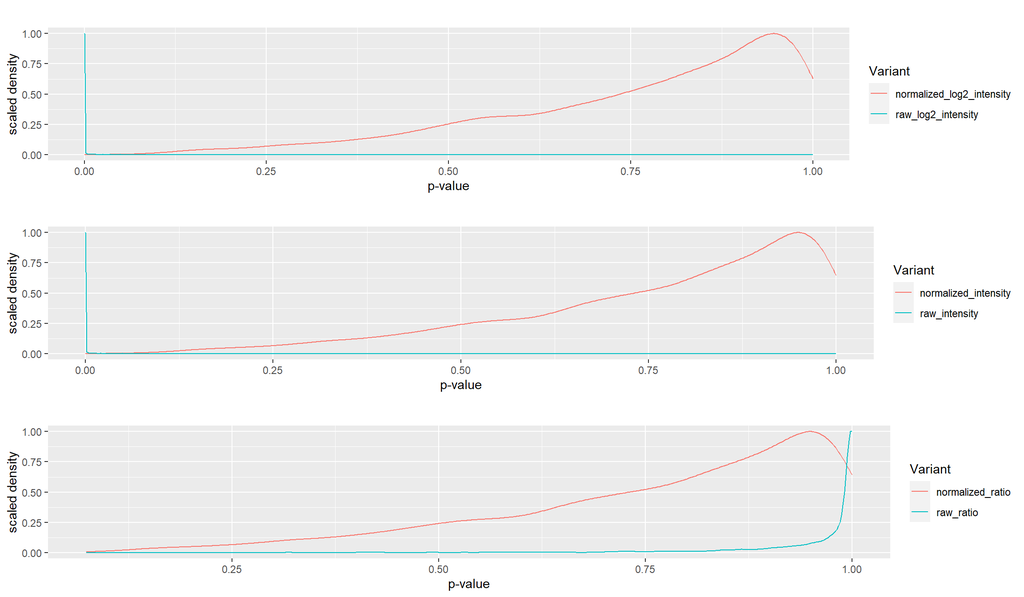

```r
plots <- vector('list', n.comp.variants)
for (i in 1:n.comp.variants){
dat <- list(dat.nonnorm.summ.l[[variant.names[i]]], dat.norm.summ.l[[variant.names[i]]])
names(dat) <- c(paste('raw', variant.names[i], sep='_'), paste('normalized', variant.names[i], sep='_'))
plots[[i]] <- run_effect_plot(dat)}
grid.arrange(grobs = plots, nrow=n.comp.variants)
```

# 6 DEA component: Moderated t-test

NOTE: - actually, lmFit (used in moderated_ttest) was built for log2-transformed data. However, supplying untransformed intensities can also work. This just means that the effects in the linear model are also additive on the untransformed scale, whereas for log-transformed data they are multiplicative on the untransformed scale. Also, there may be a bias which occurs from biased estimates of the population means in the t-tests, as mean(X) is not equal to exp(mean(log(X))).

```r
if (!load_outputdata){
#{ INVESTIGATE late log2 transform
dat.norm.summ.w2$intensity_lateLog2 <- dat.norm.summ.w2$intensity
channelNames.prefixed <- colnames(dat.norm.summ.w2$intensity %>% select(-Protein))
dat.norm.summ.w2$intensity_lateLog2[,channelNames.prefixed] <- log2(dat.norm.summ.w2$intensity[,channelNames.prefixed])
variant.names <- names(dat.norm.summ.w2)
scale.vec <- c(scale.vec, 'log')
n.comp.variants <- n.comp.variants + 1
#}
design.matrix <- get_design_matrix(referenceCondition, sample.info)
dat.dea <- emptyList(names(dat.norm.summ.w2))
for (i in 1:n.comp.variants) {
  this_scale <- scale.vec[match(names(dat.dea)[i], variant.names)]
  d <- column_to_rownames(as.data.frame(dat.norm.summ.w2[[variant.names[i]]]), 'Protein')
  dat.dea[[variant.names[i]]] <- moderated_ttest(dat=d, design.matrix, scale=this_scale)
}
}
```

# 7 Results comparison

## 7.1 Confusion matrix

```r
cm <- conf_mat(dat.dea, 'q.mod', 0.05, spiked.proteins)
print_conf_mat(cm, referenceCondition)
```

|  | 0.125 vs 0.5 contrast log2_intensity background | 0.125 vs 0.5 contrast log2_intensity spiked | 0.125 vs 0.5 contrast intensity background | 0.125 vs 0.5 contrast intensity spiked | 0.125 vs 0.5 contrast ratio background | 0.125 vs 0.5 contrast ratio spiked | 0.125 vs 0.5 contrast intensity_lateLog2 background | 0.125 vs 0.5 contrast intensity_lateLog2 spiked |
| --- | --- | --- | --- | --- | --- | --- | --- | --- |
| not_DE | 4061 | 4 | 4062 | 7 | 4062 | 7 | 4061 | 4 |
| DE | 3 | 15 | 2 | 12 | 2 | 12 | 3 | 15 |

|  | 0.125 vs 0.5 contrast log2_intensity | 0.125 vs 0.5 contrast intensity | 0.125 vs 0.5 contrast ratio | 0.125 vs 0.5 contrast intensity_lateLog2 |
| --- | --- | --- | --- | --- |
| Accuracy | 0.998 | 0.998 | 0.998 | 0.998 |
| Sensitivity | 0.789 | 0.632 | 0.632 | 0.789 |
| Specificity | 0.999 | 1.000 | 1.000 | 0.999 |
| PPV | 0.833 | 0.857 | 0.857 | 0.833 |
| NPV | 0.999 | 0.998 | 0.998 | 0.999 |

|  | 0.667 vs 0.5 contrast log2_intensity background | 0.667 vs 0.5 contrast log2_intensity spiked | 0.667 vs 0.5 contrast intensity background | 0.667 vs 0.5 contrast intensity spiked | 0.667 vs 0.5 contrast ratio background | 0.667 vs 0.5 contrast ratio spiked | 0.667 vs 0.5 contrast intensity_lateLog2 background | 0.667 vs 0.5 contrast intensity_lateLog2 spiked |
| --- | --- | --- | --- | --- | --- | --- | --- | --- |
| not_DE | 4062 | 17 | 4062 | 15 | 4062 | 15 | 4062 | 17 |
| DE | 2 | 2 | 2 | 4 | 2 | 4 | 2 | 2 |

|  | 0.667 vs 0.5 contrast log2_intensity | 0.667 vs 0.5 contrast intensity | 0.667 vs 0.5 contrast ratio | 0.667 vs 0.5 contrast intensity_lateLog2 |
| --- | --- | --- | --- | --- |
| Accuracy | 0.995 | 0.996 | 0.996 | 0.995 |
| Sensitivity | 0.105 | 0.211 | 0.211 | 0.105 |
| Specificity | 1.000 | 1.000 | 1.000 | 1.000 |
| PPV | 0.500 | 0.667 | 0.667 | 0.500 |
| NPV | 0.996 | 0.996 | 0.996 | 0.996 |

|  | 1 vs 0.5 contrast log2_intensity background | 1 vs 0.5 contrast log2_intensity spiked | 1 vs 0.5 contrast intensity background | 1 vs 0.5 contrast intensity spiked | 1 vs 0.5 contrast ratio background | 1 vs 0.5 contrast ratio spiked | 1 vs 0.5 contrast intensity_lateLog2 background | 1 vs 0.5 contrast intensity_lateLog2 spiked |
| --- | --- | --- | --- | --- | --- | --- | --- | --- |
| not_DE | 4060 | 5 | 4059 | 3 | 4059 | 3 | 4059 | 5 |
| DE | 4 | 14 | 5 | 16 | 5 | 16 | 5 | 14 |

|  | 1 vs 0.5 contrast log2_intensity | 1 vs 0.5 contrast intensity | 1 vs 0.5 contrast ratio | 1 vs 0.5 contrast intensity_lateLog2 |
| --- | --- | --- | --- | --- |
| Accuracy | 0.998 | 0.998 | 0.998 | 0.998 |
| Sensitivity | 0.737 | 0.842 | 0.842 | 0.737 |
| Specificity | 0.999 | 0.999 | 0.999 | 0.999 |
| PPV | 0.778 | 0.762 | 0.762 | 0.737 |
| NPV | 0.999 | 0.999 | 0.999 | 0.999 |

## 7.2 Scatter plots

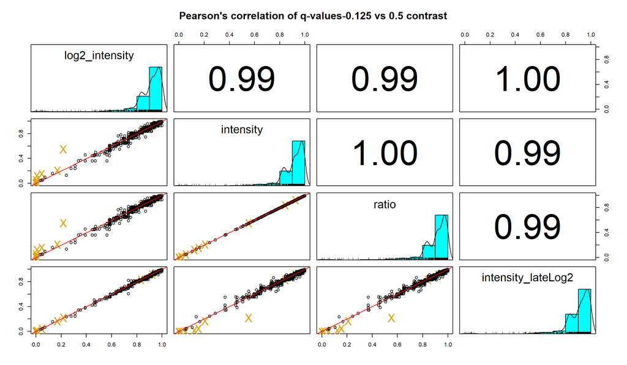

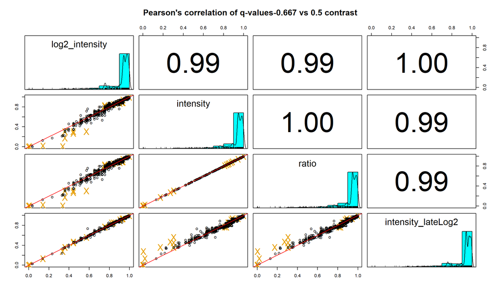

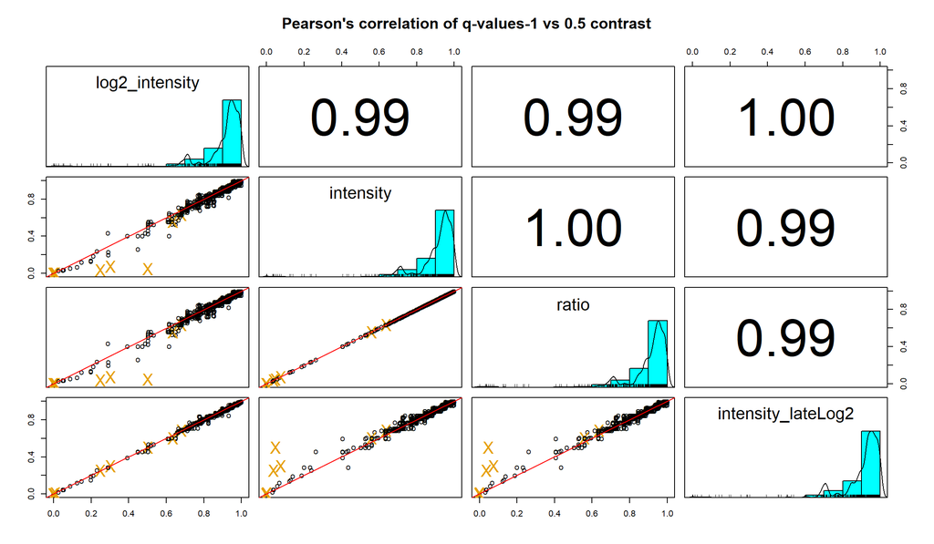

```r
# character vectors containing logFC and p-values columns
dea.cols <- colnames(dat.dea[[1]])
logFC.cols <- dea.cols[stri_detect_fixed(dea.cols, 'logFC')]
significance.cols <- dea.cols[stri_detect_fixed(dea.cols, 'q.mod')]
n.contrasts <- length(logFC.cols)

scatterplot_ils(dat.dea, significance.cols, 'q-values', spiked.proteins)
```

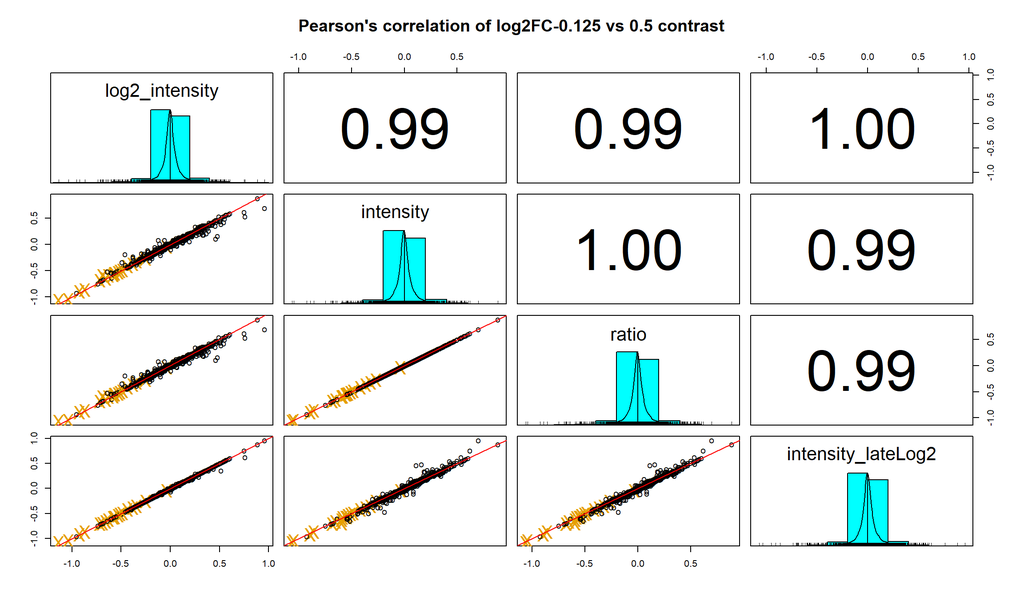

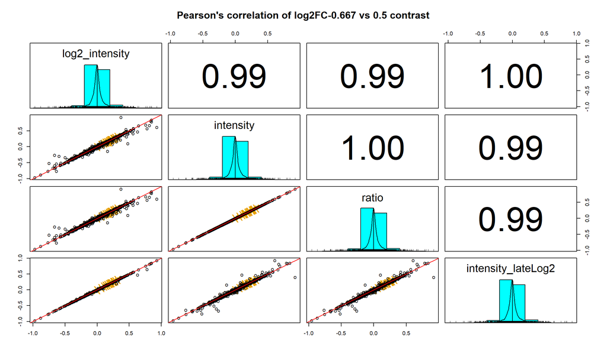

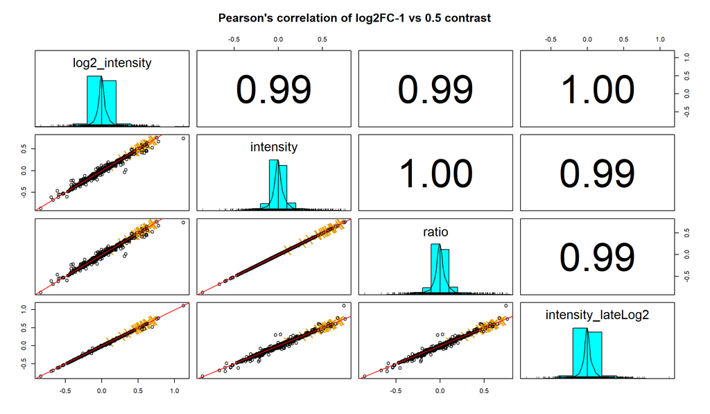

```r
scatterplot_ils(dat.dea, logFC.cols, 'log2FC', spiked.proteins)
```

## 7.3 Volcano plots

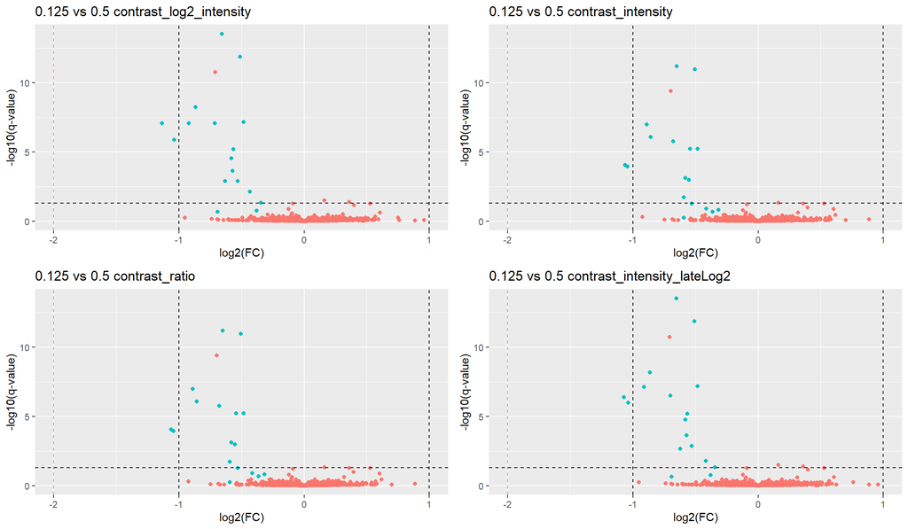

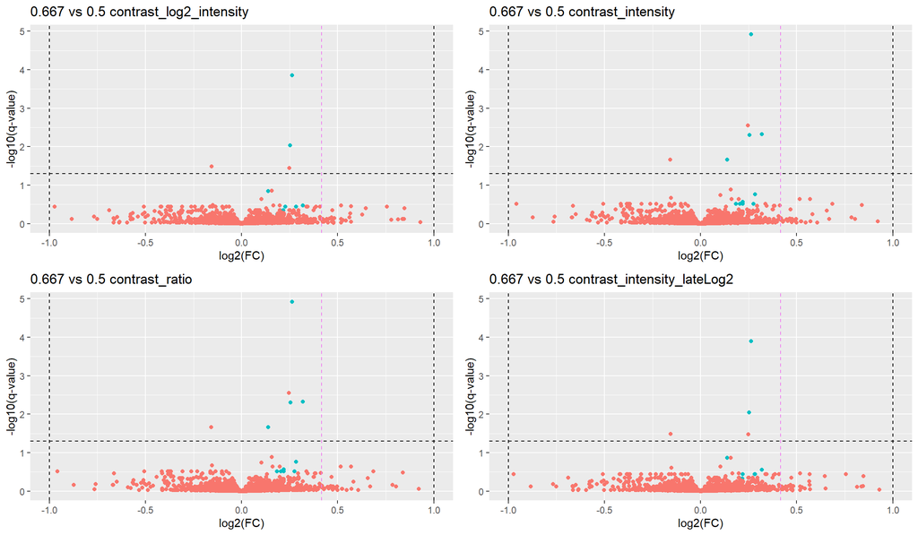

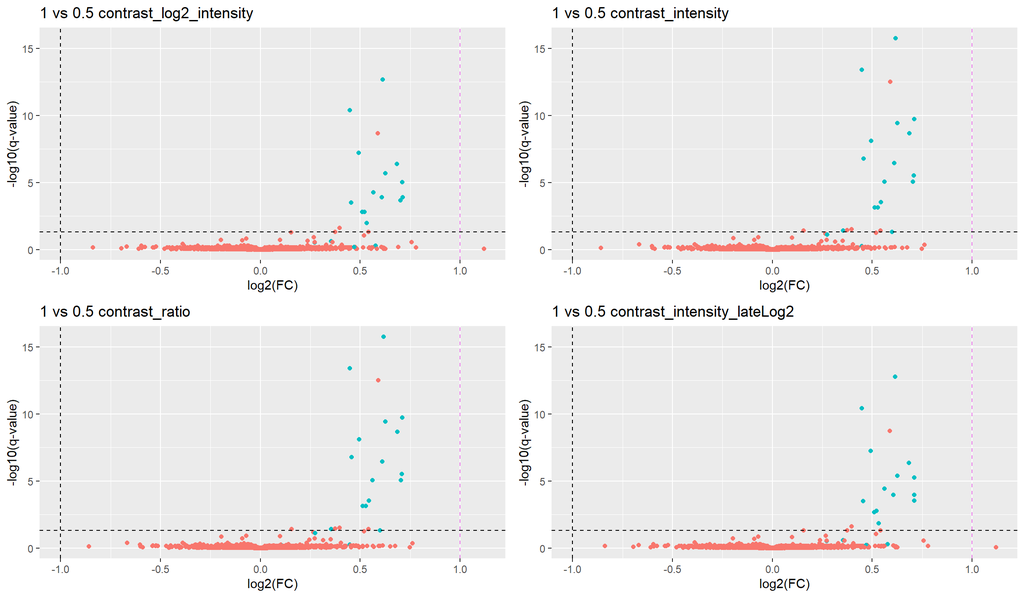

```r
for (i in 1:n.contrasts){
  volcanoplot_ils(dat.dea, i, spiked.proteins)}
```

## 7.4 Violin plots

Let’s see whether the spiked protein fold changes make sense

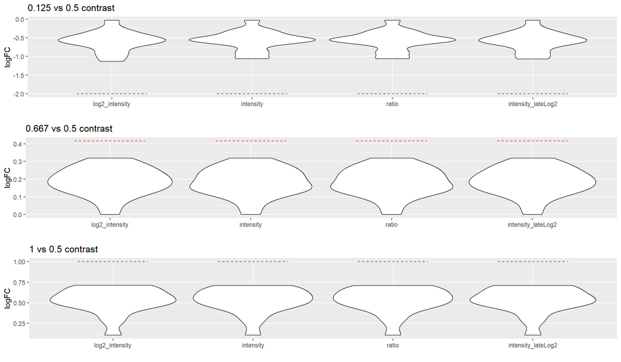

```r
# plot theoretical value (horizontal lines) and violin per variant
violinplot_ils(lapply(dat.dea, function(x) x[spiked.proteins, logFC.cols]), referenceCondition)
```

# 8 Conclusions